# Manipulación Demanda de Combustible 2013-2021

Irma Noemí No

2021-11-10

# 1 Análisis de la Información

## 1.1 Importamos los datos

Las datos a trabajar pertenecen a `bases` abiertas y oficiales obtenidas a través de la página: [datos.gob.ar](https://datos.gob.ar/)

| Año | idmes | Empresa | cuit | planta | producto | provincia | localidad | Unidad_Volumen | Unidad_Precio | Precio_de_venta | Venta_Directa_Volumen | Otros_Precio | Otros_Volumen | exento | movimientos | fecha | fecha_carga | bandera estacion de servicio |
| --- | --- | --- | --- | --- | --- | --- | --- | --- | --- | --- | --- | --- | --- | --- | --- | --- | --- | --- |
| 2013 | 4 | Refinor | 30658233692 | BANDA DEL RIO SALI - Refinor | GAS OIL GRADO 2 | TUCUMAN | BANDA DEL RIO SALI | m3 | $/Litro | 3.6310 | 14999.0 | NA | NA | NO | Si | 2013-04-01 | 2013-05-10 | Refinor |
| 2013 | 4 | Refinor | 30658233692 | BANDA DEL RIO SALI - Refinor | Nafta común sin plomo, hasta 92 RON | TUCUMAN | BANDA DEL RIO SALI | m3 | $/Litro | 2.6750 | 1487.0 | NA | NA | NO | Si | 2013-04-01 | 2013-05-10 | Refinor |
| 2013 | 4 | Refinor | 30658233692 | BANDA DEL RIO SALI - Refinor | Nafta premium sin plomo, de mas de 95 RON | TUCUMAN | BANDA DEL RIO SALI | m3 | $/Litro | 3.6350 | 672.0 | NA | NA | NO | Si | 2013-04-01 | 2013-05-10 | Refinor |
| 2013 | 1 | SUALIER SA | 30707592865 | HURLINGHAM - SUALIER SA | Nafta premium sin plomo, de mas de 95 RON | BUENOS AIRES | HURLINGHAM | m3 | $/Litro | NA | NA | 4.085 | 43 | NO | Si | 2013-01-01 | 2013-03-01 | SUALIER SA |
| 2013 | 1 | SUALIER SA | 30707592865 | HURLINGHAM - SUALIER SA | Nafta súper sin plomo, de mas de 92 RON | BUENOS AIRES | HURLINGHAM | m3 | $/Litro | NA | NA | 3.620 | 338 | NO | Si | 2013-01-01 | 2013-03-01 | SUALIER SA |
| 2013 | 1 | SUALIER SA | 30707592865 | HURLINGHAM - SUALIER SA | GAS OIL GRADO 3 | BUENOS AIRES | HURLINGHAM | m3 | $/Litro | 3.5100 | 133.0 | NA | NA | NO | Si | 2013-01-01 | 2013-03-01 | SUALIER SA |
| 2013 | 4 | Refinor | 30658233692 | BANDA DEL RIO SALI - Refinor | Nafta súper sin plomo, de mas de 92 RON | TUCUMAN | BANDA DEL RIO SALI | m3 | $/Litro | 3.4000 | 10076.0 | NA | NA | NO | Si | 2013-04-01 | 2013-05-10 | Refinor |
| 2013 | 4 | Petrobras Energia S.A. | 30504077078 | NA | Nafta premium sin plomo, de mas de 95 RON | NA | NA | m3 | $/Litro | 3.6657 | 459.5 | NA | NA | NO | Si | 2013-04-01 | 2013-05-23 | Petrobras Energia S.A. |
| 2013 | 1 | OIL COMBUSTIBLES S.A. | 30711293988 | SAN LORENZO - OIL COMBUSTIBLES S.A. | GAS OIL GRADO 2 | SANTA FE | SAN LORENZO | m3 | $/Litro | 3.5400 | 27538.8 | NA | NA | NO | Si | 2013-01-01 | 2013-03-05 | OIL COMBUSTIBLES S.A. |
| 2013 | 1 | OIL COMBUSTIBLES S.A. | 30711293988 | SAN LORENZO - OIL COMBUSTIBLES S.A. | GAS OIL GRADO 2 | SANTA FE | SAN LORENZO | m3 | $/Litro | 3.5400 | 7311.4 | NA | NA | SI | Si | 2013-01-01 | 2013-03-05 | OIL COMBUSTIBLES S.A. |

## 1.2 Análisis Descriptivos

### 1.2.1 Comportamiento anual

Un primer análisis de la demanda de combustible muy poco desagregada es la consideración conjunta por año.

Totales de ventas anuales y Promedios de demandas

| Año | Total | Promedio | DesvioSD |
| --- | --- | --- | --- |
| 2019 | 7813296 | 6321.44 | 18327.28 |
| 2017 | 7348386 | 4981.96 | 8937.61 |
| 2013 | 7178180 | 4469.60 | 8273.58 |
| 2018 | 7044844 | 5230.03 | 9521.04 |
| 2016 | 7041154 | 4428.40 | 8003.05 |
| 2015 | 6983351 | 4276.39 | 7695.01 |
| 2014 | 6787547 | 4083.96 | 7582.04 |
| 2020 | 6362346 | 5181.06 | 9910.21 |
| 2021 | 4700268 | 5649.36 | 11444.14 |

Desde la tabla observamos un enorme desvío correspondiente a la elevada variabilidad de pedidos por períodos mensuales y diversas órdenes de diferentes empresas, destacándose los años de 2021 (cuyos datos están incompletos por estar en curso y de allí su comportamiento atípico) y el año 2019, cuyos valores se deberán analizar.

Realizamos un pequeño gráfico:

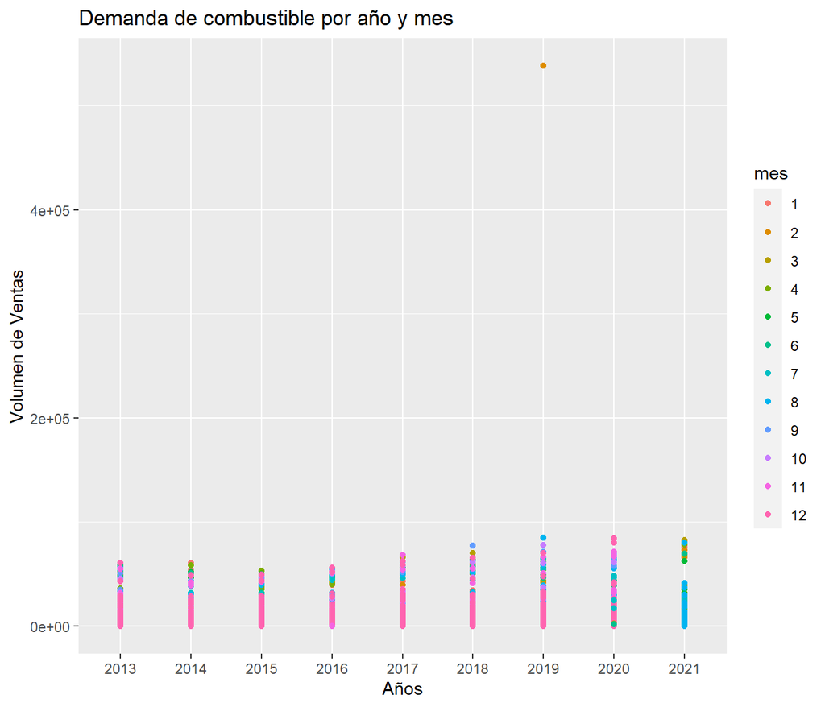

Efectivamente el año 2019 contiene un dato aislado discordante con el comportamiento general observado, cambiamos la escala para analizar el comportamiento mensual en una vista conjunta de mayor detalle.

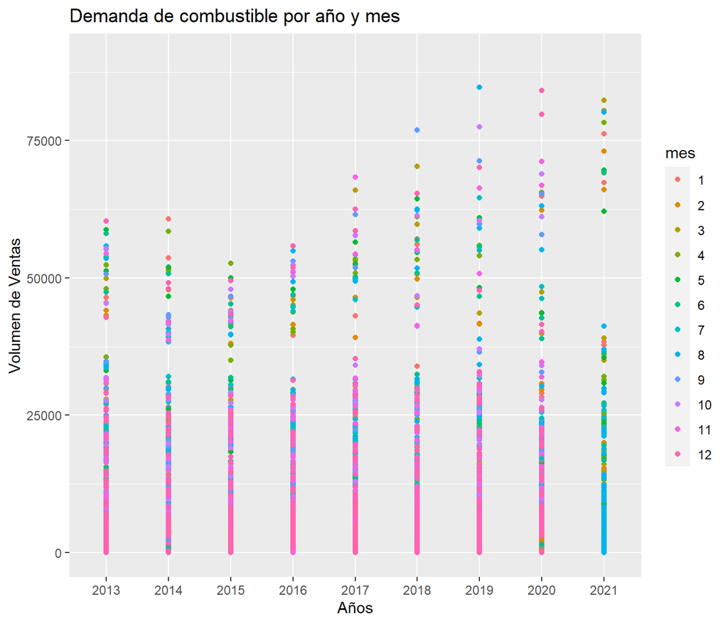

Observando en detalle el gráfico anterior, se ve que en el año 2020 el comportamiento del volumen de ventas ha sido diferencial con respecto a los años anteriores. Si confeccionamos una tabla y un gráfico de barras con la demanda total de los meses 4, 5 y 6 es posible que observemos las diferencias que creemos ver.

| Año | Mes 4 | Mes 5 | Mes 6 |
| --- | --- | --- | --- |
| 2013 | 622700.5 | 618812.3 | 572887.7 |
| 2014 | 579375.8 | 543761.8 | 531898.1 |
| 2015 | 617978.2 | 568050.4 | 570592.1 |
| 2016 | 531196.9 | 550527.6 | 567080.3 |
| 2017 | 559109.3 | 608471.6 | 602348.6 |
| 2018 | 541342.3 | 565660.8 | 576284.8 |
| 2019 | 590457.1 | 585821.1 | 573593.3 |
| 2020 | 368101.0 | 430225.1 | 470105.3 |
| 2021 | 624519.4 | 562648.3 | 498494.0 |

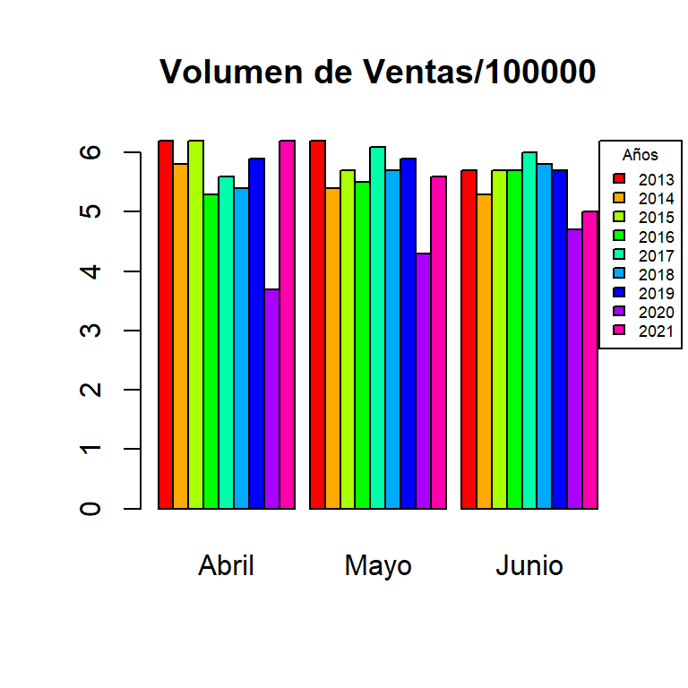

## 1.3 Comparativos con 2020

Analizamos el comportamiento antes y después de 2020.

### 1.3.1 Diagramas de Cajas

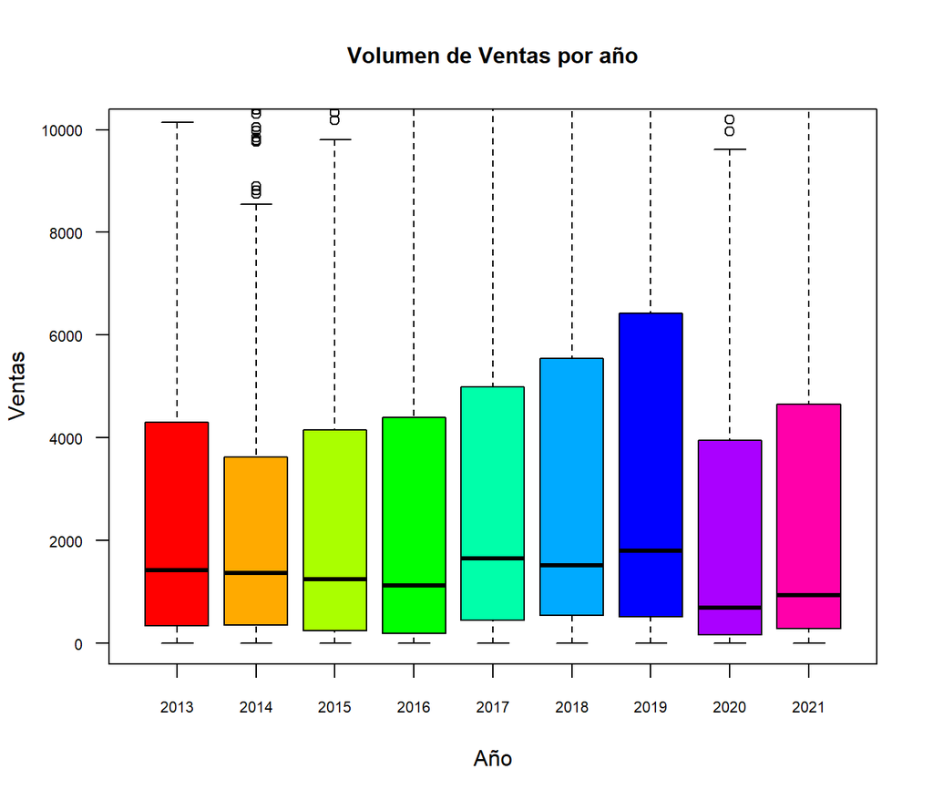

### 1.3.2 Dispersión (últimos años)

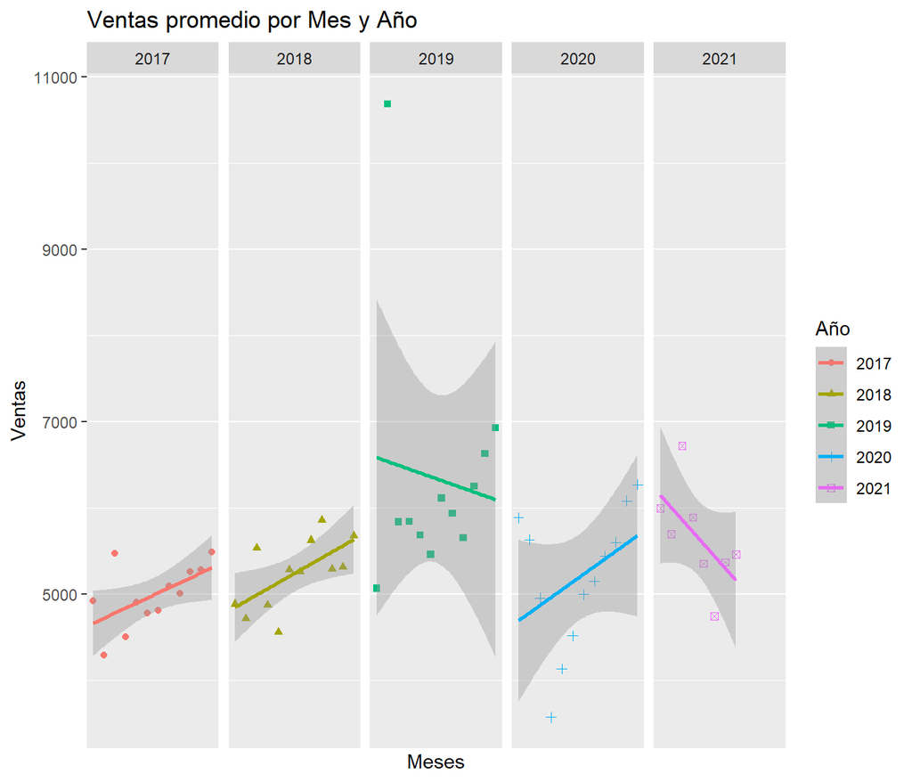

# 2 Estimaciones de Demanda